# PracticalMachineLearning_Week4

WENCAI

5 Mai 2019

## 0. Introduction

This project is part of the coursera course practical machine learning week 4 assignment. Background is the collected acceleromotors data from 6 participants. Target is to train a modell in order to predict the manner of their activities, which correspond to the “classes” variable in the data set.

## 1. Data Cleasing

Load the packages and download the data as indicated

```r
library(caret)
library(rattle)
library(dplyr)
trainURL<-"https://d396qusza40orc.cloudfront.net/predmachlearn/pml-training.csv"
testURL<-"https://d396qusza40orc.cloudfront.net/predmachlearn/pml-testing.csv"
train_raw<-read.csv(trainURL,na.strings=c("NA","","#DIV/0!"))
test_raw<-read.csv(testURL,na.strings=c("NA","","#DIV/0!"))
str(train_raw)
```

```
## 'data.frame':    19622 obs. of  160 variables:
##  $ X                       : int  1 2 3 4 5 6 7 8 9 10 ...
##  $ user_name               : Factor w/ 6 levels "adelmo","carlitos",..: 2 2 2 2 2 2 2 2 2 2 ...
##  $ raw_timestamp_part_1    : int  1323084231 1323084231 1323084231 1323084232 1323084232 1323084232 1323084232 1323084232 1323084232 1323084232 ...
##  $ raw_timestamp_part_2    : int  788290 808298 820366 120339 196328 304277 368296 440390 484323 484434 ...
##  $ cvtd_timestamp          : Factor w/ 20 levels "02/12/2011 13:32",..: 9 9 9 9 9 9 9 9 9 9 ...
##  $ new_window              : Factor w/ 2 levels "no","yes": 1 1 1 1 1 1 1 1 1 1 ...
##  $ num_window              : int  11 11 11 12 12 12 12 12 12 12 ...
##  $ roll_belt               : num  1.41 1.41 1.42 1.48 1.48 1.45 1.42 1.42 1.43 1.45 ...
##  $ pitch_belt              : num  8.07 8.07 8.07 8.05 8.07 8.06 8.09 8.13 8.16 8.17 ...
##  $ yaw_belt                : num  -94.4 -94.4 -94.4 -94.4 -94.4 -94.4 -94.4 -94.4 -94.4 -94.4 ...
##  $ total_accel_belt        : int  3 3 3 3 3 3 3 3 3 3 ...
##  $ kurtosis_roll_belt      : num  NA NA NA NA NA NA NA NA NA NA ...
##  $ kurtosis_picth_belt     : num  NA NA NA NA NA NA NA NA NA NA ...
##  $ kurtosis_yaw_belt       : logi  NA NA NA NA NA NA ...
```

[output cut: 86 more lines]

compare the column name values between the two data sets

```r
colnames(train_raw)==colnames(test_raw)
```

```
##   [1]  TRUE  TRUE  TRUE  TRUE  TRUE  TRUE  TRUE  TRUE  TRUE  TRUE  TRUE
##  [12]  TRUE  TRUE  TRUE  TRUE  TRUE  TRUE  TRUE  TRUE  TRUE  TRUE  TRUE
##  [23]  TRUE  TRUE  TRUE  TRUE  TRUE  TRUE  TRUE  TRUE  TRUE  TRUE  TRUE
##  [34]  TRUE  TRUE  TRUE  TRUE  TRUE  TRUE  TRUE  TRUE  TRUE  TRUE  TRUE
##  [45]  TRUE  TRUE  TRUE  TRUE  TRUE  TRUE  TRUE  TRUE  TRUE  TRUE  TRUE
##  [56]  TRUE  TRUE  TRUE  TRUE  TRUE  TRUE  TRUE  TRUE  TRUE  TRUE  TRUE
##  [67]  TRUE  TRUE  TRUE  TRUE  TRUE  TRUE  TRUE  TRUE  TRUE  TRUE  TRUE
##  [78]  TRUE  TRUE  TRUE  TRUE  TRUE  TRUE  TRUE  TRUE  TRUE  TRUE  TRUE
##  [89]  TRUE  TRUE  TRUE  TRUE  TRUE  TRUE  TRUE  TRUE  TRUE  TRUE  TRUE
## [100]  TRUE  TRUE  TRUE  TRUE  TRUE  TRUE  TRUE  TRUE  TRUE  TRUE  TRUE
## [111]  TRUE  TRUE  TRUE  TRUE  TRUE  TRUE  TRUE  TRUE  TRUE  TRUE  TRUE
## [122]  TRUE  TRUE  TRUE  TRUE  TRUE  TRUE  TRUE  TRUE  TRUE  TRUE  TRUE
## [133]  TRUE  TRUE  TRUE  TRUE  TRUE  TRUE  TRUE  TRUE  TRUE  TRUE  TRUE
## [144]  TRUE  TRUE  TRUE  TRUE  TRUE  TRUE  TRUE  TRUE  TRUE  TRUE  TRUE
## [155]  TRUE  TRUE  TRUE  TRUE  TRUE FALSE
```

```r
test_raw<-dplyr::select(test_raw,-problem_id)
```

As we can see the last column is different. And that column is problem id, which is a redundant of the entry id. So it is removed

We can see there is a lot of NA values in a lot of columns.Also the first 5 columns are purely framework information (user and timestamp), which will not bring value as predictors and can be removed.Then we will do the nearZeroVa to remove the variables with less variance.

```r
remove_col<-colnames(train_raw)[1:5]
train_raw<-dplyr::select(train_raw,-remove_col)
test_raw<-dplyr::select(test_raw,-remove_col)
## remove columns with NA values
train_raw<-train_raw[,colSums(is.na(train_raw))==0]
nzv_tr<-nearZeroVar(train_raw,saveMetrics=TRUE)
train_raw<-train_raw[,nzv_tr$nzv==FALSE]
print(dim(train_raw))
```

```
## [1] 19622    54
```

We finally get 54 variables. The last column of the train_raw would be classe. Except that paricular column, the rest of the columns should be remained in the test raw.

```r
remain_col<-colnames(train_raw)[1:53]
test_raw<-dplyr::select(test_raw,remain_col)
dim(test_raw)
```

```
## [1] 20 53
```

## 2. Train the model

Now we are finished with the variables. We can start to train the model based on the current data set. First we do the training and testing spitting due to the cross validation purpose.

```r
inTrain<-createDataPartition(y=train_raw$classe,p=0.6,list=FALSE)
testset<-train_raw[-inTrain,]
trainset<-train_raw[inTrain,]
dim(trainset)
```

```
## [1] 11776    54
```

The first model we will try is decission Tree.

```r
mod_dt<-train(classe~.,data=trainset,method="rpart")
print(table(predict(mod_dt,trainset),trainset$classe))
```

```
##
##        A    B    C    D    E
##   A 3064  973  967  876  300
##   B   55  570   35  316  130
##   C  222  736 1052  738  763
##   D    0    0    0    0    0
##   E    7    0    0    0  972
```

```r
print(table(predict(mod_dt,testset),testset$classe))
```

```
##
##        A    B    C    D    E
##   A 2016  613  625  578  223
##   B   29  390   19  228   80
##   C  180  515  724  480  480
##   D    0    0    0    0    0
##   E    7    0    0    0  659
```

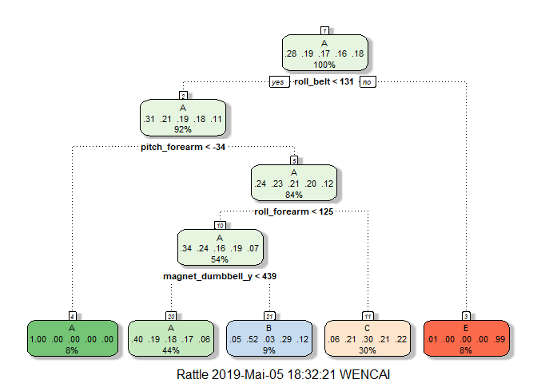

```r
rattle::fancyRpartPlot(mod_dt$finalModel)
```

Apparently the model and the result is not satisfying. Let’s take a look at the accuracy.

```r
sum(predict(mod_dt,testset)==testset$classe)/dim(testset)[1]
```

```
## [1] 0.4829212
```

The second model we use is random forest.

```r
mod_rf<-train(classe~.,data=trainset,method="rf",
              trControl=trainControl(method="cv",number=6))
print(table(predict(mod_rf,trainset),trainset$classe))
```

```
##
##        A    B    C    D    E
##   A 3348    0    0    0    0
##   B    0 2279    0    0    0
##   C    0    0 2054    0    0
##   D    0    0    0 1930    0
##   E    0    0    0    0 2165
```

```r
print(table(predict(mod_rf,testset),testset$classe))
```

```
##
##        A    B    C    D    E
##   A 2232    8    0    0    0
##   B    0 1508    4    0    2
##   C    0    1 1364    3    0
##   D    0    1    0 1283    7
##   E    0    0    0    0 1433
```

Apparently the result is much better. So we will decide to use this random forest model

```r
predict_rf<-predict(mod_rf,testset)
print(sum(predict_rf==testset$classe)/dim(testset)[1])
```

```
## [1] 0.9966862
```

```r
confusionMatrix(predict_rf, testset$classe)
```

```
## Confusion Matrix and Statistics
##
##           Reference
## Prediction    A    B    C    D    E
##          A 2232    8    0    0    0
##          B    0 1508    4    0    2
##          C    0    1 1364    3    0
##          D    0    1    0 1283    7
##          E    0    0    0    0 1433
##
## Overall Statistics
##
##                Accuracy : 0.9967
##                  95% CI : (0.9951, 0.9978)
##     No Information Rate : 0.2845
##     P-Value [Acc > NIR] : < 2.2e-16
##
##                   Kappa : 0.9958
##
##  Mcnemar's Test P-Value : NA
##
## Statistics by Class:
##
##                      Class: A Class: B Class: C Class: D Class: E
## Sensitivity            1.0000   0.9934   0.9971   0.9977   0.9938
## Specificity            0.9986   0.9991   0.9994   0.9988   1.0000
## Pos Pred Value         0.9964   0.9960   0.9971   0.9938   1.0000
## Neg Pred Value         1.0000   0.9984   0.9994   0.9995   0.9986
## Prevalence             0.2845   0.1935   0.1744   0.1639   0.1838
## Detection Rate         0.2845   0.1922   0.1738   0.1635   0.1826
## Detection Prevalence   0.2855   0.1930   0.1744   0.1645   0.1826
## Balanced Accuracy      0.9993   0.9962   0.9982   0.9982   0.9969
```

3. Use the model to predict

```r
predict_result<-predict(mod_rf,test_raw)
print(predict_result)
```

```
##  [1] B A B A A E D B A A B C B A E E A B B B
## Levels: A B C D E
```